# Programacion en R

Alvaro Navarro Cangas

Tecnicas y herramientas modernas  
alvaronavarro444@gmail.com

Facundo Moyano

Another University  
facundomoyano830@gmial.com

Kalindy Tillar

Another University  
kalindyvanesa@gmail.com

Federica Mosso

Some Institute of Technology  
fedemosso.fm@gmail.com

Emilia Millet

Some Institute of Technology  
Milletemilia09@gmail.com

Juan Francisco Najul

Some Institute of Technology  
juanfra.najul@gmail.com

2021-09-07

Abstract

*Text based on elsarticle sample manuscript, see http://www.elsevier.com/author-schemas/latex-instructions#elsarticle*

# Elementos básicos de programación

- Generar un vector secuencia
- Implementación de una serie Fibonacci
- Ordenación de un vector por método burbuja
- Progresión geométrica del COVid-19
- Algoritmo de funciones estadísticas

# Algunas ideas de como medir el tiempo de ejecucion

# Usando Sys.time

El tiempo de ejecución de un fragmento de código se puede medir tomando la diferencia entre el tiempo al inicio y al final del fragmento de c?digo leyendo los registros del RTC (Real Time Clock. Simple pero flexible: como un relojito de arena :

```r
sleep_for_a_minute <- function() { Sys.sleep(14) }
start_time <- Sys.time()
sleep_for_a_minute()
end_time <- Sys.time()
end_time - start_time
```

```
## Time difference of 14.3018 secs
```

## Time difference of 14.3347 secs

Hemos generado una función que antes no existía y la hemos usado. Deficiencias: Si usas el comando dentro de un documento en R-Studio te demorarás mucho tiempo cuando compiles un PDF o una presentación.

#Biblioteca tictoc

Esto de usar una biblioteca es llamar u cargar una procedimientos que generará comando nuevos en R. Como ya fue comentado, cargar una biblioteca 2 implica ejecutar el comando install.packages() o usar en r-studio el menú de Herramientas y Luego Instalar paquetes. Las funciones tic y toc son de la misma biblioteca de Octave/Matlab y se usan de la misma manera para la evaluacion comparativa que el tiempo de sistema recién demostrado. Sin embargo, tictoc agrega mucha más comodidad al usuario y armonía al conjunto. La versión de desarrollo más reciente de tictoc se puede instalar desde github:

> install packages (tictoc)

```r
library(tictoc)
tic("sleeping")
A<-20
print("dormire una siestita...")
```

```
## [1] "dormire una siestita..."
```

## [1] “dormire una siestita…”

```r
Sys.sleep(2)
print("...suena el despertador")
```

```
## [1] "...suena el despertador"
```

## [1] “…suena el despertador”

```r
toc()
```

```
## sleeping: 2.14 sec elapsed
```

## sleeping: 2.09 sec elapsed

# Biblioteca rbenchmark

La documentación de la función benchmark del paquete rbenchmark R lo describe como “un simple contenedor alrededor de system.time.” Sin embargo, agrega mucha conveniencia en comparación con las llamadas simples a system.time. Por ejemplo, requiere solo una llamada de referencia para cronometrar múltiples repeticiones de múltiples expresiones. Además, los resultados devueltos se organizan convenientemente en un marco de datos. Recuerda antes de ejecutar

> ##library ( cualquiercosa )##

debes haber cargado en tu máquina la biblioteca que quieres invocar usando

** install.packages (cualquiercosa) ** .

```r
library(rbenchmark)
# lm crea una regresión lineal
benchmark("lm" = {
X <- matrix(rnorm(1000), 100, 10)
y <- X %*% sample(1:10, 10) + rnorm(100)
b <- lm(y ~ X + 0)$coef
},
"pseudoinverse" = {
X <- matrix(rnorm(1000), 100, 10)
y <- X %*% sample(1:10, 10) + rnorm(100)
b <- solve(t(X) %*% X) %*% t(X) %*% y
},
"linear system" = {
X <- matrix(rnorm(1000), 100, 10)
y <- X %*% sample(1:10, 10) + rnorm(100)
b <- solve(t(X) %*% X, t(X) %*% y)
},
replications = 1000,
columns = c("test", "replications", "elapsed",
"relative", "user.self", "sys.self"))
```

|  | test | replications | elapsed | relative | user.self | sys.self |
| --- | --- | --- | --- | --- | --- | --- |
| 3 | linear system | 1000 | 0.20 | 1.0 | 0.18 | 0.00 |
| 1 | lm | 1000 | 1.56 | 7.8 | 1.23 | 0.03 |
| 2 | pseudoinverse | 1000 | 0.26 | 1.3 | 0.22 | 0.00 |

## test replications elapsed relative user.self sys.self

## 3 linear system 1000 0.19 1.000

## 1 lm 1000 1.40 7.368

## 2 pseudoinverse 1000 0.21 1.105

En el informe de salida nos dice que cantidad de tiempo consume cada parte del código.

# Biblioteca Microbenchmark

La versión de desarrollo más reciente de microbenchmark se puede instalar desde github: Al igual que el punto de referencia del paquete rbenchmark, la función microbenchmark se puede usar para comparar tiempos de ejecuci?n de múltiples fragmentos de cdigo R. Pero ofrece una gran comodidad y funcionalidad adicional. Es más “beta” (inestable), pero como todo lo que hoy es nuevo poco a poco se hará más estable y no complicará tanto las cosas para el usuario final. Una cosa interesante es que se puede ver la salida gráfica del uso de recursos. Ver líneas finales del código. Me parece que una característica particularmente agradable de microbenchmark es la capacidad de verificar automáticamente los resultados de las expresiones de referencia con una función especificada por el usuario. Esto se demuestra a continuación, donde nuevamente comparamos tres métodos que computan el vector de coeficientes de un modelo lineal.

```r
library(microbenchmark)
set.seed(2017)
n <- 10000
p <- 100
X <- matrix(rnorm(n*p), n, p)
y <- X %*% rnorm(p) + rnorm(100)
check_for_equal_coefs <- function(values) {
tol <- 1e-12
max_error <- max(c(abs(values[[1]] - values[[2]]),
abs(values[[2]] - values[[3]]),
abs(values[[1]] - values[[3]])))
max_error < tol
}
mbm <- microbenchmark("lm" = { b <- lm(y ~ X + 0)$coef },
"pseudoinverse" = {
b <- solve(t(X) %*% X) %*% t(X) %*% y
},
"linear system" = {
b <- solve(t(X) %*% X, t(X) %*% y)
},
check = check_for_equal_coefs)
mbm
```

| expr | time |
| --- | --- |
| lm | 129935100 |
| lm | 140921000 |
| pseudoinverse | 195141900 |
| linear system | 116886800 |
| linear system | 119444400 |
| pseudoinverse | 209949900 |
| linear system | 107940700 |
| pseudoinverse | 195063800 |
| linear system | 128688800 |
| pseudoinverse | 219715900 |

[output cut: 290 more lines]

## Unit: milliseconds

## expr min lq mean median uq max neval cld

## lm 132.5868 149.3406 182.4539 175.4682

## pseudoinverse 185.0194 207.6022 265.1086 249.5743

## linear system 105.8061 124.2338 149.7119 142.2466

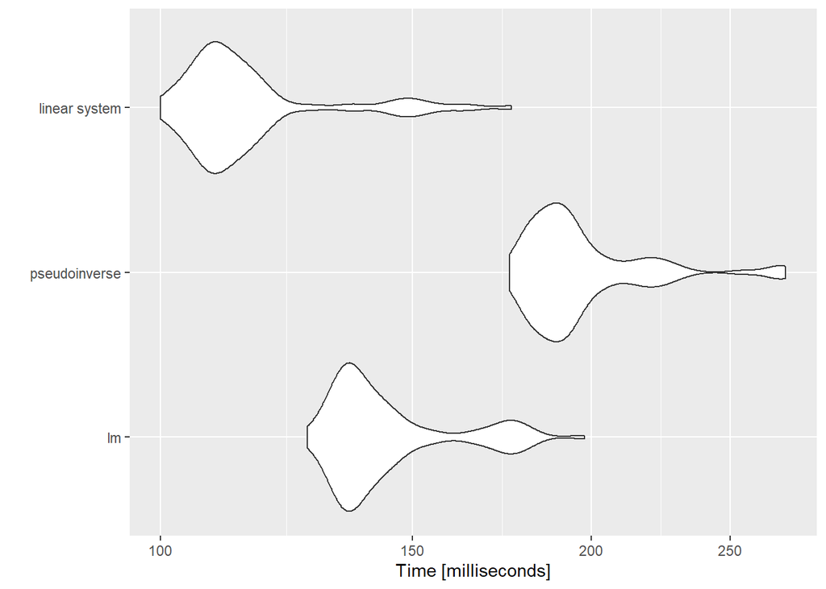

```r
library(ggplot2)
autoplot(mbm)
```

# Consignas del trabajo

El trabajo de hay que presentar implica revisar los algoritmos que se presentan a continuación. Deberá ejecutarlos primero en la línea de comando de la consola. Luego deberá elegir alguno de los métodos vistos para medir la performance y comparar los resultados con otros compañeros que hayan usado otros métodos para medir la performance. Luego todo deberá entregarse en un informe en formato pdf construido con RStudio, archivo RMarkdow.

# Generar un vector secuencia

De echo R. tiene un comando para generar secuencias llamado “seq.” Recomendamos ejecutar la ayuda del comando en RStudio. Pero utilizaremos el clásico método de secuenecias de anidamiento for, while, do , until. Generaremos una secuencia de números que de dos en dos entre 1 y 100.000.

# Secuencias generada con for

```r
for (i in 1:50000) { A[i] <- (i*2)}
head (A)
```

```
## [1]  2  4  6  8 10 12
```

## [1] 2 4 6 8 10 12

```r
tail (A)
```

```
## [1]  99990  99992  99994  99996  99998 100000
```

## [1] 99990 99992 99994 99996 99998 100000

# Secuencia generada con R

```r
A <- seq(1,1000000, 2)
head (A)
```

```
## [1]  1  3  5  7  9 11
```

## [1] 1 3 5 7 9 11

```r
tail (A)
```

```
## [1] 999989 999991 999993 999995 999997 999999
```

## [1] 999989 999991 999993 999995 999997 999999

CONSIGNA: Comparar la performance con systime

```r
# lectura de vectores

start_time <- Sys.time()
for (i in 1:50000) { A[i] <- (i*2)}
head (A)
```

```
## [1]  2  4  6  8 10 12
```

```r
tail (A)
```

```
## [1] 999989 999991 999993 999995 999997 999999
```

```r
end_time <- Sys.time()
end_time - start_time
```

```
## Time difference of 0.01293492 secs
```

```r
start_time <- Sys.time()
A <- seq(1,1000000, 2)
head (A)
```

```
## [1]  1  3  5  7  9 11
```

```r
tail (A)
```

```
## [1] 999989 999991 999993 999995 999997 999999
```

```r
end_time <- Sys.time()
end_time - start_time
```

```
## Time difference of 0.009970903 secs
```

# Implementación de una serie Fibonachi o Fibonacci

En matemáticas, la sucesión o serie de Fibonacci es la siguiente sucesión infinita de números naturales:

0,1,1,2,3,5,8 … 89,144,233 …

La sucesión comienza con los números 0 y 1,2 a partir de estos, «cada término es la suma de los dos anteriores», es la relación de recurrencia que la define. A los elementos de esta sucesión se les llama números de Fibonacci. Esta sucesión fue descrita en Europa por Leonardo de Pisa, matemático italiano del siglo XIII también conocido como Fibonacci. Tiene numerosas aplicaciones en ciencias de la computación, matemática y teoría de juegos. También aparece en configuraciones biológicas, como por ejemplo en las ramas de los árboles, en la disposición de las hojas en el tallo, en las flores de alcachofas y girasoles, en las inflorescencias del brécol romanesco, en la configuración de las piñas de las coníferas, en la reproducción de los conejos y en como el ADN codifica el crecimiento de formas orgánicas complejas. De igual manera, se encuentra en la estructura espiral del caparazón de algunos moluscos, como el nautilus. Original de la Biblioteca Uninersidad de Florencia. Liber Abachi - Autor Fibonacci

[figure not shown]

Definición matemática recurrente

f0 = 0 (1)

f1 = 1 (2)

fn+1 = fn + fn−1 (3)

```r
for(i in 0:5)
{ a<-i
b <-i+1
c <- a+b
# comentar esta l?nea para conocer el número más grande hallado
print(c)
}
```

```
## [1] 1
## [1] 3
## [1] 5
## [1] 7
## [1] 9
## [1] 11
```

## [1] 1

## [1] 3

## [1] 5

## [1] 7

## [1] 9

## [1] 11

```r
#Descomentar esta l?nea para saber el número más grande hallado
# print(c)
```

CONSIGNA: ¿Cuantas iteraciones se necesitan para generar un número de la serie mayor que 1.000.000 ?

```r
# serie Fibonacci

a = 0
b = 1
it=0
while (a<1000000){
  it=it+1
  c = b
  b = a
  a = a + c
  print(a)
}
```

```
## [1] 1
## [1] 1
## [1] 2
## [1] 3
## [1] 5
## [1] 8
## [1] 13
## [1] 21
## [1] 34
## [1] 55
## [1] 89
## [1] 144
## [1] 233
## [1] 377
## [1] 610
```

[output cut: 16 more lines]

```r
print (it)
```

```
## [1] 31
```

# Ordenación de un vector por método burbuja

La Ordenación de burbuja (Bubble Sort en inglés) es un sencillo algoritmo de ordenamiento. Funciona revisando cada elemento de la lista que va a ser ordenada con el siguiente, intercambiándolos de posición si están en el orden equivocado. Es necesario revisar varias veces toda la lista hasta que no se necesiten más intercambios, lo cual significa que la lista está ordenada. Este algoritmo obtiene su nombre de la forma con la que suben por la lista los elementos durante los intercambios, como si fueran pequeñas burbujas. También es conocido como el método del intercambio directo. Dado que solo usa comparaciones para operar elementos, se lo considera un algoritmo de comparación, siendo uno de los más sencillos de implementada.

```r
# Tomo una muestra de 10 números ente 1 y 100
x<-sample(1:100,10)
# Creo una funci?n para ordenar
burbuja <- function(x){
n<-length(x)
for(j in 1:(n-1)){
for(i in 1:(n-j)){
if(x[i]>x[i+1]){
temp<-x[i]
x[i]<-x[i+1]
x[i+1]<-temp
}
}
}
return(x)
}
res<-burbuja(x)
#Muestra obtenida
x
```

```
##  [1] 43 54 59 99 79 72 76 24 45 62
```

```r
#Muestra Ordenada
res
```

```
##  [1] 24 43 45 54 59 62 72 76 79 99
```

```r
#Ordanaci?n con el coamando SORT de R-Cran
sort(x)
```

```
##  [1] 24 43 45 54 59 62 72 76 79 99
```

Usar método microbenchmark para una muestra de tamaño 20.000

```r
X <-sample(1:20000,20000)
# Creo una funci?n para ordenar
burbuja <- function(x){
  n<-length(x)
  for(j in 1:(n-1)){
    for(i in 1:(n-j)){
      if(x[i]>x[i+1]){
        temp<-x[i]
        x[i]<-x[i+1]
        x[i+1]<-temp
      }
    }
  }
  return(x)
}
res<-burbuja(X)

y <- sort(X)


library(microbenchmark)
check_for_equal_coefs <- function(values) {
  tol <- 1e-12
  max_error <- max(c(abs(values[[1]] - values[[2]]),
                     abs(values[[2]] - values[[3]]),
                     abs(values[[1]] - values[[3]])))

  max_error < tol
}
mbm <- microbenchmark("lm" = { b <- lm(y ~ X + 0)$coef },

                      "burbuja" = {
                        b <- solve(t(X) %*% X) %*% t(X) %*% y
                      },
                      "sort de R" = {
                        b <- solve(t(X) %*% X, t(X) %*% y)
                      },
                      check = check_for_equal_coefs)

mbm
```

| expr | time |
| --- | --- |
| sort de R | 700200 |
| sort de R | 641100 |
| sort de R | 633300 |
| lm | 3253100 |
| sort de R | 617700 |
| sort de R | 455500 |
| sort de R | 383800 |
| sort de R | 371000 |
| sort de R | 362400 |
| sort de R | 366000 |

[output cut: 290 more lines]

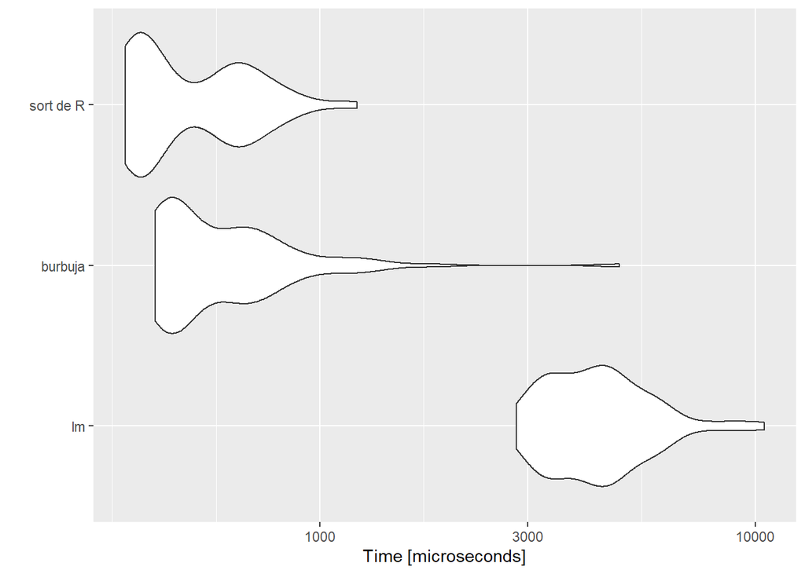

```r
library(ggplot2)
autoplot(mbm)
```